# R Notebook

```r
library(readr)
library(FactoMineR)
library(ggfortify)
library(psych)
```

```r
library(corrplot)
library(devtools)
data <- read.csv("C:/Users/rusha/Downloads/Multivariate/mva class social media.csv")
str(data)
```

```
## 'data.frame':    21 obs. of  11 variables:
##  $ Instagram                 : num  3.8 7.7 3.8 5.4 0 2.3 5.4 7 8.7 0.2 ...
##  $ Linkedin                  : num  4 5.2 7 5.32 0.58 7 4 4 10 0 ...
##  $ Snapchat                  : num  0.96 3.6 0.48 1.2 0 0.48 0 3.12 3.84 0 ...
##  $ Twitter                   : num  5.04 0 0 0 0.72 0 0 0 0 0 ...
##  $ Whatsapp..Wechat          : num  0.96 4.08 9.84 5.28 3.12 ...
##  $ Youtube                   : num  2.4 4.32 1.92 1.92 3.6 6.96 3.12 1.92 4.08 3.12 ...
##  $ OTT                       : num  14.4 0 1.92 1.92 1.92 3.12 0 3.12 3.12 0 ...
##  $ Reddit                    : num  12 0 0 0 0.96 0 0 0 0 0 ...
##  $ Mood.Productivity         : int  1 1 1 1 1 1 1 1 1 0 ...
##  $ Tired.waking.up.in.morning: int  0 0 0 0 1 0 1 1 0 0 ...
##  $ Trouble.falling.asleep    : int  0 1 0 0 1 0 0 1 0 0 ...
```

```r
#data$OTT <- data$OTT..Netflix..Hulu..Prime.video..
summary(data)
```

```
##    Instagram         Linkedin         Snapchat        Twitter
##  Min.   : 0.000   Min.   : 0.000   Min.   :0.000   Min.   :0.0000
##  1st Qu.: 3.800   1st Qu.: 1.920   1st Qu.:0.000   1st Qu.:0.0000
##  Median : 5.400   Median : 3.920   Median :0.480   Median :0.0000
##  Mean   : 5.381   Mean   : 3.641   Mean   :1.303   Mean   :0.9829
##  3rd Qu.: 7.000   3rd Qu.: 5.000   3rd Qu.:1.440   3rd Qu.:0.7200
##  Max.   :15.000   Max.   :10.000   Max.   :7.200   Max.   :8.4000
##  Whatsapp..Wechat    Youtube           OTT             Reddit
##  Min.   : 0.960   Min.   :0.000   Min.   : 0.000   Min.   : 0.0000
##  1st Qu.: 3.600   1st Qu.:1.920   1st Qu.: 0.000   1st Qu.: 0.0000
##  Median : 6.000   Median :3.120   Median : 1.680   Median : 0.0000
##  Mean   : 6.433   Mean   :2.994   Mean   : 2.377   Mean   : 0.9829
##  3rd Qu.: 8.880   3rd Qu.:4.080   3rd Qu.: 2.400   3rd Qu.: 0.0000
##  Max.   :15.360   Max.   :6.960   Max.   :14.400   Max.   :12.0000
##  Mood.Productivity Tired.waking.up.in.morning Trouble.falling.asleep
##  Min.   :0.0000    Min.   :0.0000             Min.   :0.0000
##  1st Qu.:1.0000    1st Qu.:0.0000             1st Qu.:0.0000
##  Median :1.0000    Median :0.0000             Median :0.0000
##  Mean   :0.9524    Mean   :0.3333             Mean   :0.3333
##  3rd Qu.:1.0000    3rd Qu.:1.0000             3rd Qu.:1.0000
##  Max.   :1.0000    Max.   :1.0000             Max.   :1.0000
```

```r
stddata <- scale(data)
stddata
```

```
##          Instagram    Linkedin    Snapchat     Twitter Whatsapp..Wechat
##  [1,] -0.458572372  0.14585097 -0.19080356  1.89964558      -1.35232307
##  [2,]  0.672664895  0.63331045  1.27838387 -0.46019583      -0.58144950
##  [3,] -0.458572372  1.36449966 -0.45792855 -0.46019583       0.84170169
##  [4,]  0.005524968  0.68205640 -0.05724107 -0.46019583      -0.28495967
##  [5,] -1.560803555 -1.24340854 -0.72505354 -0.12307563      -0.81864137
##  [6,] -0.893663628  1.36449966 -0.45792855 -0.46019583       1.37538339
##  [7,]  0.005524968  0.14585097 -0.72505354 -0.46019583      -0.10706577
##  [8,]  0.469622309  0.14585097  1.01125888 -0.46019583       0.90099966
##  [9,]  0.962725733  2.58314836  1.41194637 -0.46019583      -0.04776781
## [10,] -1.502791388 -1.47901395 -0.72505354 -0.46019583      -1.35232307
## [11,] -0.226523702 -0.61377338 -0.45792855  0.66353817      -1.35232307
## [12,] -0.603602791 -0.46347338 -0.59149105  0.88828497      -0.70004544
## [13,]  0.034531052 -0.71938960 -0.19080356 -0.46019583      -0.58144950
## [14,]  0.179561471 -0.26036526 -0.19080356 -0.01070223      -0.75934340
## [15,] -0.197517618  0.04429691  0.07632143 -0.46019583       0.01153016
## [16,]  0.469622309  0.55206720 -0.45792855 -0.46019583      -0.34425764
## [17,]  1.281792654 -1.15404097 -0.72505354 -0.34782243       1.73117118
## [18,]  0.411610141 -0.69907879  0.34344641 -0.46019583       0.13012609
## [19,]  0.092543220  0.11335367 -0.72505354 -0.46019583       0.60450982
## [20,]  2.790109010  0.12554016  3.28182129 -0.46019583       2.20555492
## [21,] -1.473785304 -1.26778151 -0.72505354  3.47287318       0.48097239
##           Youtube          OTT       Reddit Mood.Productivity
##  [1,] -0.34318162  3.416542553  3.741995242         0.2182179
##  [2,]  0.76555900 -0.675514117 -0.333829451         0.2182179
##  [3,] -0.62036678 -0.129906561 -0.333829451         0.2182179
##  [4,] -0.62036678 -0.129906561 -0.333829451         0.2182179
##  [5,]  0.34978127 -0.129906561 -0.007763476         0.2182179
##  [6,]  2.29007736  0.211098162 -0.333829451         0.2182179
##  [7,]  0.07259611 -0.675514117 -0.333829451         0.2182179
##  [8,] -0.62036678  0.211098162 -0.333829451         0.2182179
##  [9,]  0.62696642  0.211098162 -0.333829451         0.2182179
## [10,]  0.07259611 -0.675514117 -0.333829451        -4.3643578
## [11,] -1.17473709 -0.675514117 -0.333829451         0.2182179
## [12,] -0.34318162 -0.266308450 -0.333829451         0.2182179
## [13,] -1.17473709 -0.402710339 -0.252312957         0.2182179
## [14,] -0.34318162 -0.402710339 -0.333829451         0.2182179
## [15,]  0.07259611 -0.129906561  2.030148871         0.2182179
## [16,]  1.18133674 -0.402710339 -0.170796463         0.2182179
## [17,]  0.34978127 -0.198107505 -0.333829451         0.2182179
```

[output cut: 37 more lines]

```
##     Trouble.falling.asleep
##                  0.3333333
## attr(,"scaled:scale")
##                  Instagram                   Linkedin
##                  3.4475526                  2.4617431
##                   Snapchat                    Twitter
##                  1.7969116                  2.1357367
##           Whatsapp..Wechat                    Youtube
##                  4.0473563                  1.7316945
##                        OTT                     Reddit
##                  3.5190128                  2.9441894
##          Mood.Productivity Tired.waking.up.in.morning
##                  0.2182179                  0.4830459
##     Trouble.falling.asleep
##                  0.4830459
```

```r
datacov <- cov(data)
datacov
```

```
##                             Instagram   Linkedin    Snapchat     Twitter
## Instagram                  11.8856190  2.6722190  4.70125714 -3.03674286
## Linkedin                    2.6722190  6.0601790  1.65757714 -1.74098286
## Snapchat                    4.7012571  1.6575771  3.22889143 -0.96438857
## Twitter                    -3.0367429 -1.7409829 -0.96438857  4.56137143
## Whatsapp..Wechat            7.3121667  2.2435667  2.79984000 -1.80920000
## Youtube                     1.7086857  1.8679257  0.73645714 -1.73650286
## OTT                         3.7723429  1.6087429  2.89110857  1.51830857
## Reddit                     -1.4035429  0.1178171 -0.24438857  2.04425143
## Mood.Productivity           0.2590476  0.1820476  0.06514286  0.04914286
## Tired.waking.up.in.morning -0.2833333 -0.3798333 -0.13200000  0.11200000
## Trouble.falling.asleep      0.4566667 -0.1378333  0.33600000 -0.18800000
##                            Whatsapp..Wechat      Youtube        OTT      Reddit
## Instagram                        7.31216667  1.708685714  3.7723429 -1.40354286
## Linkedin                         2.24356667  1.867925714  1.6087429  0.11781714
## Snapchat                         2.79984000  0.736457143  2.8911086 -0.24438857
## Twitter                         -1.80920000 -1.736502857  1.5183086  2.04425143
## Whatsapp..Wechat                16.38109333  2.606240000  1.9884800 -3.48848000
## Youtube                          2.60624000  2.998765714  0.9157029 -0.25906286
## OTT                              1.98848000  0.915702857 12.3834514  6.98166857
## Reddit                          -3.48848000 -0.259062857  6.9816686  8.66825143
## Mood.Productivity                0.27366667 -0.006285714  0.1188571  0.04914286
## Tired.waking.up.in.morning      -0.06866667 -0.280000000 -0.3640000 -0.26000000
## Trouble.falling.asleep          -0.11566667  0.056000000  0.0200000 -0.26000000
##                            Mood.Productivity Tired.waking.up.in.morning
## Instagram                        0.259047619                -0.28333333
## Linkedin                         0.182047619                -0.37983333
## Snapchat                         0.065142857                -0.13200000
## Twitter                          0.049142857                 0.11200000
## Whatsapp..Wechat                 0.273666667                -0.06866667
## Youtube                         -0.006285714                -0.28000000
## OTT                              0.118857143                -0.36400000
## Reddit                           0.049142857                -0.26000000
## Mood.Productivity                0.047619048                 0.01666667
## Tired.waking.up.in.morning       0.016666667                 0.23333333
## Trouble.falling.asleep           0.016666667                 0.08333333
##                            Trouble.falling.asleep
## Instagram                              0.45666667
## Linkedin                              -0.13783333
## Snapchat                               0.33600000
## Twitter                               -0.18800000
## Whatsapp..Wechat                      -0.11566667
## Youtube                                0.05600000
## OTT                                    0.02000000
## Reddit                                -0.26000000
## Mood.Productivity                      0.01666667
## Tired.waking.up.in.morning             0.08333333
## Trouble.falling.asleep                 0.23333333
```

```r
# Formatting
datacov_rounded <- round(datacov, digits = 2)
datacov_df <- as.data.frame(datacov_rounded)
datacov_df
```

|  | Instagram | Linkedin | Snapchat | Twitter | Whatsapp..Wechat | Youtube | OTT | Reddit | Mood.Productivity | Tired.waking.up.in.morning | Trouble.falling.asleep |
| --- | --- | --- | --- | --- | --- | --- | --- | --- | --- | --- | --- |
| Instagram | 11.89 | 2.67 | 4.70 | -3.04 | 7.31 | 1.71 | 3.77 | -1.40 | 0.26 | -0.28 | 0.46 |
| Linkedin | 2.67 | 6.06 | 1.66 | -1.74 | 2.24 | 1.87 | 1.61 | 0.12 | 0.18 | -0.38 | -0.14 |
| Snapchat | 4.70 | 1.66 | 3.23 | -0.96 | 2.80 | 0.74 | 2.89 | -0.24 | 0.07 | -0.13 | 0.34 |
| Twitter | -3.04 | -1.74 | -0.96 | 4.56 | -1.81 | -1.74 | 1.52 | 2.04 | 0.05 | 0.11 | -0.19 |
| Whatsapp..Wechat | 7.31 | 2.24 | 2.80 | -1.81 | 16.38 | 2.61 | 1.99 | -3.49 | 0.27 | -0.07 | -0.12 |
| Youtube | 1.71 | 1.87 | 0.74 | -1.74 | 2.61 | 3.00 | 0.92 | -0.26 | -0.01 | -0.28 | 0.06 |
| OTT | 3.77 | 1.61 | 2.89 | 1.52 | 1.99 | 0.92 | 12.38 | 6.98 | 0.12 | -0.36 | 0.02 |
| Reddit | -1.40 | 0.12 | -0.24 | 2.04 | -3.49 | -0.26 | 6.98 | 8.67 | 0.05 | -0.26 | -0.26 |
| Mood.Productivity | 0.26 | 0.18 | 0.07 | 0.05 | 0.27 | -0.01 | 0.12 | 0.05 | 0.05 | 0.02 | 0.02 |
| Tired.waking.up.in.morning | -0.28 | -0.38 | -0.13 | 0.11 | -0.07 | -0.28 | -0.36 | -0.26 | 0.02 | 0.23 | 0.08 |

[output cut: 1 more lines]

```r
datamean <-  colMeans(data)
datamean
```

```
##                  Instagram                   Linkedin
##                  5.3809524                  3.6409524
##                   Snapchat                    Twitter
##                  1.3028571                  0.9828571
##           Whatsapp..Wechat                    Youtube
##                  6.4333333                  2.9942857
##                        OTT                     Reddit
##                  2.3771429                  0.9828571
##          Mood.Productivity Tired.waking.up.in.morning
##                  0.9523810                  0.3333333
##     Trouble.falling.asleep
##                  0.3333333
```

```r
data_MD <- mahalanobis(data, datamean, datacov)
data_MD
```

```
##  [1] 17.913458  8.413360 10.873596  3.737872 12.332858 11.687880  6.131216
##  [8]  6.962855 10.378511 19.047619  9.981459  4.903319  5.156210  4.671980
## [15] 16.117190 12.133364 12.626629  9.320741  3.949377 15.587220 18.073286
```

```r
#My usage vs class
data_MD[4]
```

```
## [1] 3.737872
```

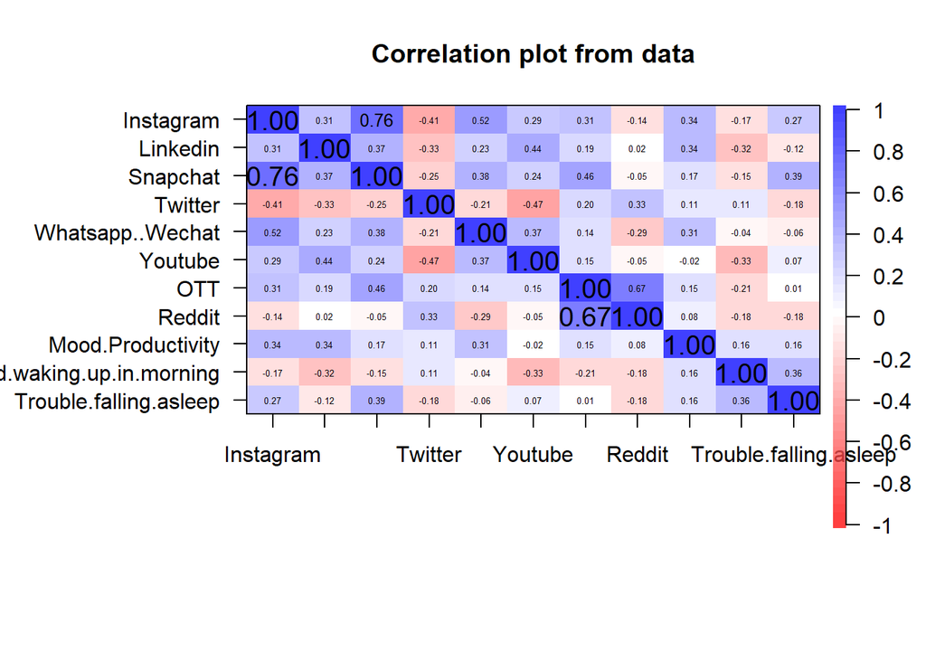

```r
# Lets plot correlation between columns
cor.plot(data)
```

Insights: 1) Instagram is highly correlated with Snapchat, Whatsapp/Wechat. 2) Tired waking up is correlated with Trouble falling asleep. 3) Trouble falling asleep is correlated with Instagram, Snapchat. 4) Tired waking up is correlated with Linkedin, Youtube but in opposite direction.

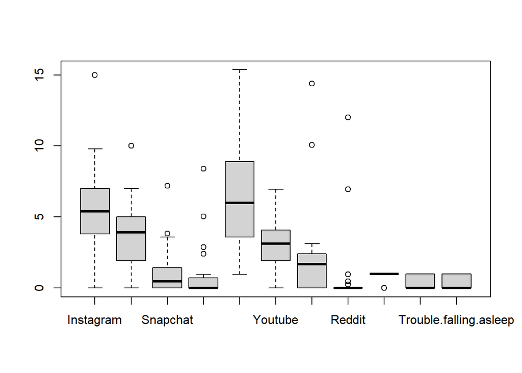

```r
#Lets identify outliers in our data
boxplot(data)
```

## Principal Component Analysis

```r
cor(data)
```

```
##                             Instagram    Linkedin   Snapchat    Twitter
## Instagram                   1.0000000  0.31486068  0.7588857 -0.4124292
## Linkedin                    0.3148607  1.00000000  0.3747178 -0.3311342
## Snapchat                    0.7588857  0.37471778  1.0000000 -0.2512914
## Twitter                    -0.4124292 -0.33113421 -0.2512914  1.0000000
## Whatsapp..Wechat            0.5240392  0.22517740  0.3849772 -0.2092991
## Youtube                     0.2862068  0.43817299  0.2366734 -0.4695226
## OTT                         0.3109420  0.18570477  0.4572112  0.2020187
## Reddit                     -0.1382767  0.01625549 -0.0461943  0.3251029
## Mood.Productivity           0.3443328  0.33888467  0.1661306  0.1054441
## Tired.waking.up.in.morning -0.1701368 -0.31941989 -0.1520753  0.1085630
## Trouble.falling.asleep      0.2742206 -0.11591060  0.3871009 -0.1822308
##                            Whatsapp..Wechat     Youtube         OTT      Reddit
## Instagram                        0.52403915  0.28620685  0.31094201 -0.13827671
## Linkedin                         0.22517740  0.43817299  0.18570477  0.01625549
## Snapchat                         0.38497724  0.23667342  0.45721117 -0.04619430
## Twitter                         -0.20929913 -0.46952261  0.20201865  0.32510290
## Whatsapp..Wechat                 1.00000000  0.37185335  0.13961399 -0.29275144
## Youtube                          0.37185335  1.00000000  0.15026660 -0.05081222
## OTT                              0.13961399  0.15026660  1.00000000  0.67386457
## Reddit                          -0.29275144 -0.05081222  0.67386457  1.00000000
## Mood.Productivity                0.30985614 -0.01663386  0.15477973  0.07648994
## Tired.waking.up.in.morning      -0.03512256 -0.33473288 -0.21413721 -0.18281811
## Trouble.falling.asleep          -0.05916275  0.06694658  0.01176578 -0.18281811
##                            Mood.Productivity Tired.waking.up.in.morning
## Instagram                         0.34433276                -0.17013685
## Linkedin                          0.33888467                -0.31941989
## Snapchat                          0.16613064                -0.15207535
## Twitter                           0.10544411                 0.10856302
## Whatsapp..Wechat                  0.30985614                -0.03512256
## Youtube                          -0.01663386                -0.33473288
## OTT                               0.15477973                -0.21413721
## Reddit                            0.07648994                -0.18281811
## Mood.Productivity                 1.00000000                 0.15811388
## Tired.waking.up.in.morning        0.15811388                 1.00000000
## Trouble.falling.asleep            0.15811388                 0.35714286
##                            Trouble.falling.asleep
## Instagram                              0.27422056
## Linkedin                              -0.11591060
## Snapchat                               0.38710088
## Twitter                               -0.18223078
## Whatsapp..Wechat                      -0.05916275
## Youtube                                0.06694658
## OTT                                    0.01176578
## Reddit                                -0.18281811
## Mood.Productivity                      0.15811388
## Tired.waking.up.in.morning             0.35714286
## Trouble.falling.asleep                 1.00000000
```

```r
data_pca <- prcomp(data,scale. =TRUE)
data_pca
```

```
## Standard deviations (1, .., p=11):
##  [1] 1.7998710 1.4207243 1.2898776 1.0720956 0.9346731 0.8336530 0.7011145
##  [8] 0.6685031 0.4353118 0.3628024 0.3172733
##
## Rotation (n x k) = (11 x 11):
##                                    PC1         PC2         PC3         PC4
## Instagram                   0.47186820 -0.04884764  0.17406705 -0.04538430
## Linkedin                    0.34972617  0.11042224 -0.23125393  0.24972996
## Snapchat                    0.44218677  0.04677477  0.22913910 -0.25646872
## Twitter                    -0.29026112  0.34035078  0.28133485  0.25180107
## Whatsapp..Wechat            0.35277134 -0.11812466  0.01625425  0.41908652
## Youtube                     0.33809163 -0.02675241 -0.35940419 -0.11528800
## OTT                         0.21670884  0.55455718  0.19911002 -0.17963493
## Reddit                     -0.05690302  0.62180558  0.07965295 -0.14829411
## Mood.Productivity           0.20165321  0.07276745  0.37665516  0.58848279
## Tired.waking.up.in.morning -0.16635987 -0.29247815  0.49676203  0.09189147
## Trouble.falling.asleep      0.13400552 -0.26021292  0.46957606 -0.45656818
##                                   PC5         PC6         PC7         PC8
## Instagram                  -0.2296125 -0.23106384  0.16211514 -0.33747912
## Linkedin                    0.5170695 -0.25827521  0.06273068  0.52177064
## Snapchat                   -0.1968548 -0.29430326 -0.02294285  0.35516621
## Twitter                    -0.2350736 -0.02994534 -0.58900395  0.31974229
## Whatsapp..Wechat           -0.4887296  0.39186342  0.02059738  0.05505523
## Youtube                     0.1978945  0.62400433 -0.34372538  0.01057310
## OTT                        -0.1173707  0.21454759  0.12927847  0.13533219
## Reddit                      0.2046397  0.20326755  0.26548909 -0.23652651
## Mood.Productivity           0.3794552 -0.05394266 -0.14333052 -0.40016089
## Tired.waking.up.in.morning  0.1579786  0.38851006  0.47340888  0.37774691
## Trouble.falling.asleep      0.2886005  0.09086092 -0.41461204 -0.07253372
##                                     PC9         PC10        PC11
## Instagram                  -0.519974578  0.065393257  0.47080732
## Linkedin                    0.102393776  0.021850575  0.35839428
## Snapchat                   -0.047160280 -0.395373121 -0.52289811
## Twitter                    -0.299849232 -0.093651730  0.23099666
## Whatsapp..Wechat            0.463543777 -0.193464652  0.19372913
## Youtube                    -0.415334208 -0.054357351 -0.14232314
## OTT                         0.128079280  0.672275563 -0.10196616
## Reddit                      0.076533237 -0.577487009  0.18113868
## Mood.Productivity          -0.003195321  0.057117649 -0.36744888
## Tired.waking.up.in.morning -0.295941729 -0.032551621  0.01473958
## Trouble.falling.asleep      0.360249366  0.002172206  0.29475585
```

```r
summary(data_pca)
```

```
## Importance of components:
##                           PC1    PC2    PC3    PC4     PC5     PC6     PC7
## Standard deviation     1.7999 1.4207 1.2899 1.0721 0.93467 0.83365 0.70111
## Proportion of Variance 0.2945 0.1835 0.1512 0.1045 0.07942 0.06318 0.04469
## Cumulative Proportion  0.2945 0.4780 0.6292 0.7337 0.81316 0.87634 0.92103
##                            PC8     PC9    PC10    PC11
## Standard deviation     0.66850 0.43531 0.36280 0.31727
## Proportion of Variance 0.04063 0.01723 0.01197 0.00915
## Cumulative Proportion  0.96166 0.97888 0.99085 1.00000
```

Insights : Keeping PC1, PC2, PC3 and PC4, as it captures ~75% of variance.

## Checking if our insight is correct

```r
(eigen_data <- data_pca$sdev^2)
```

```
##  [1] 3.2395355 2.0184576 1.6637843 1.1493891 0.8736139 0.6949774 0.4915616
##  [8] 0.4468964 0.1894964 0.1316256 0.1006623
```

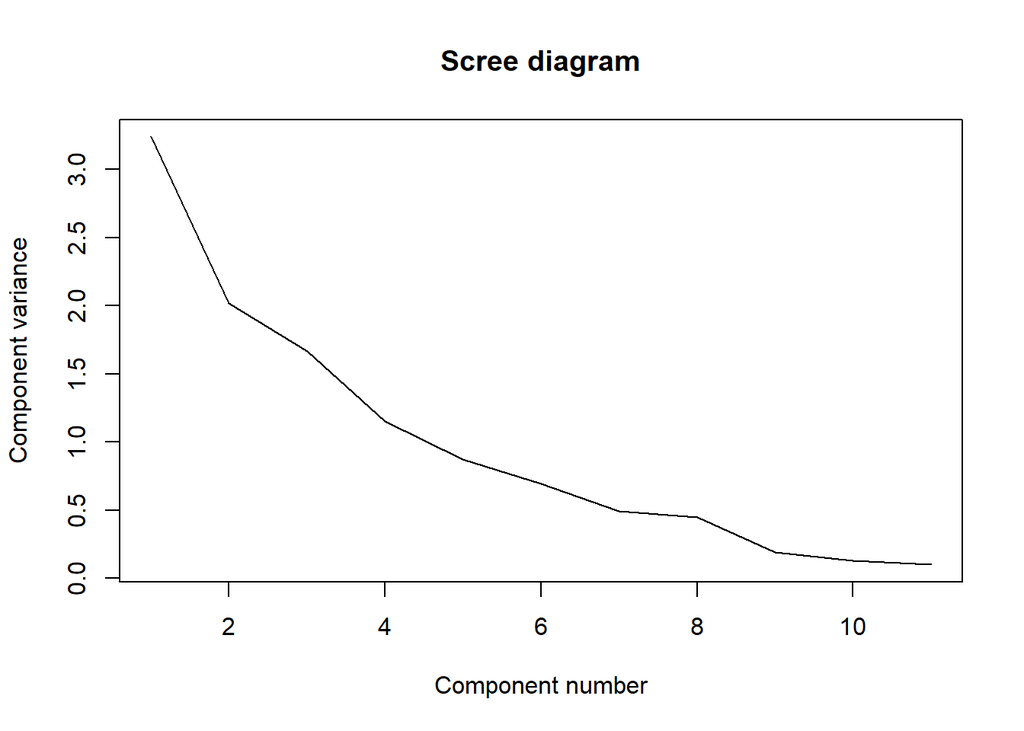

```r
plot(eigen_data, xlab = "Component number", ylab = "Component variance", type = "l", main = "Scree diagram")
```

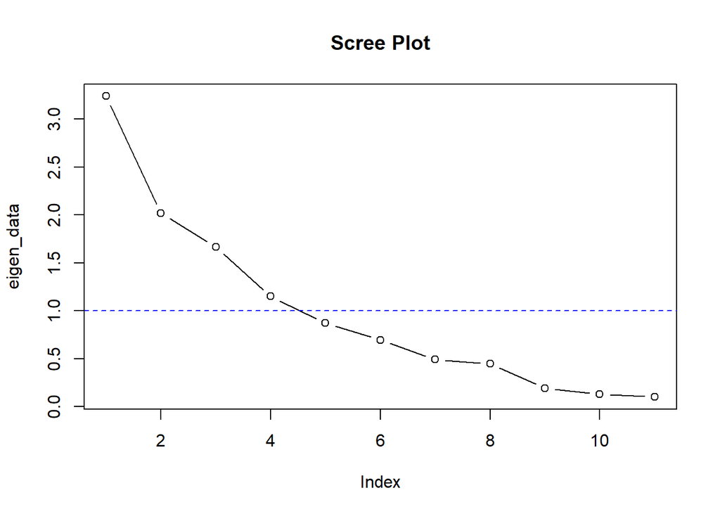

```r
plot(eigen_data, type = "b", main="Scree Plot")
abline(h=1,col="blue",lty=2)
```

```r
library(factoextra)
```

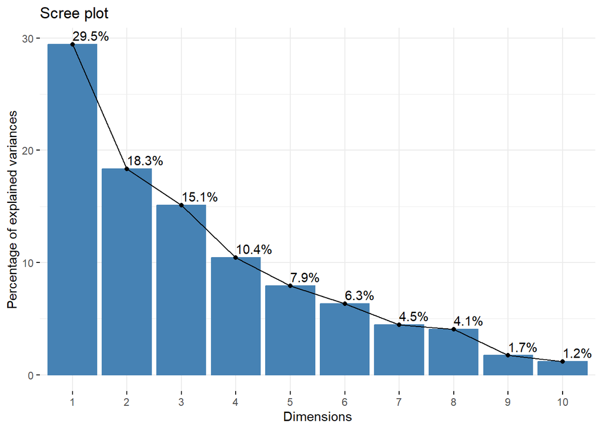

```r
fviz_eig(data_pca, addlabels = TRUE)
```

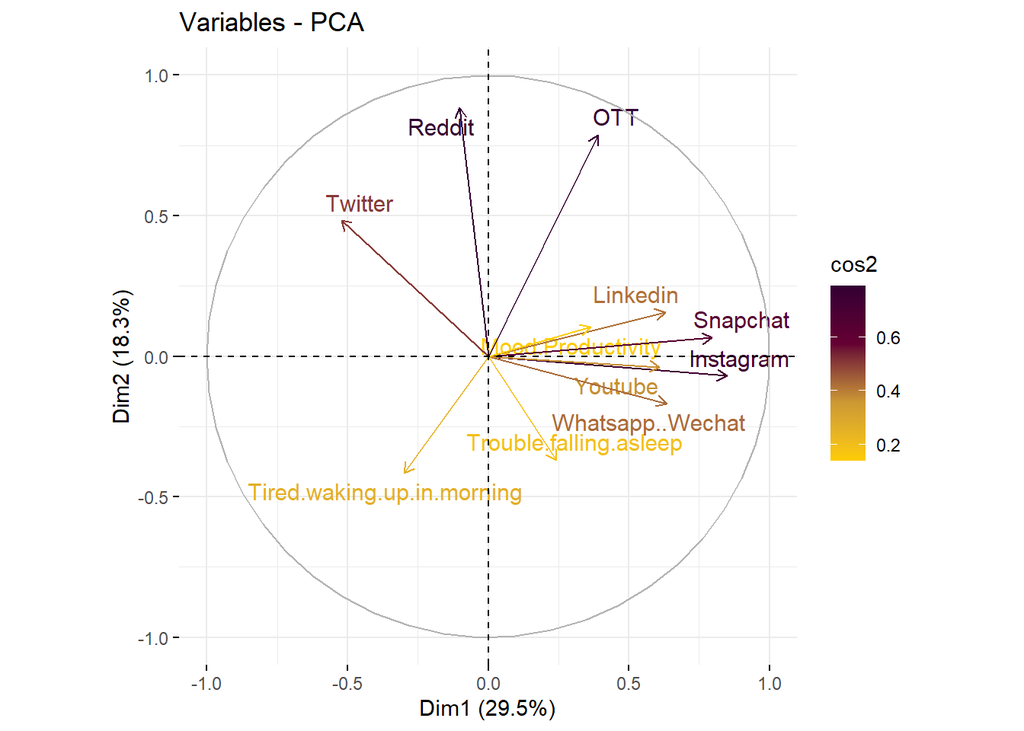

```r
fviz_pca_var(data_pca,col.var = "cos2",
             gradient.cols = c("#FFCC00", "#CC9933", "#660033", "#330033"),
             repel = TRUE)
```

Plot shows which variables are correlated. Here, Linkedin, Snapchat, Instagram, Youtube, Whatsapp/Wechat, Mood Productivity.

## Clustering

#1) Hierarchical

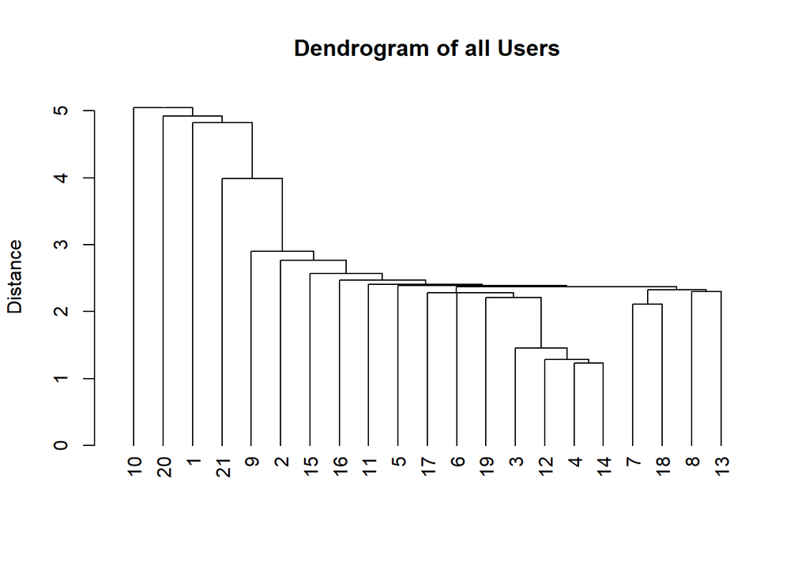

```r
library(cluster)
library(readr)
library(factoextra)
library(magrittr)
library(NbClust)

dist.data <- dist(stddata, method="euclidean")
colnames(dist.data) <- rownames(dist.data)

clusdata.nn <- hclust(dist.data, method = "single")

options(repr.plot.width=10, repr.plot.height=6)  # Adjust the plot size as needed
plot(as.dendrogram(clusdata.nn), ylab="Distance",
     main="Dendrogram of all Users")
```

Insight: I think the optimal number of clusters are 5

## Non-hierarchical clustering/ K-means clustering

```r
(kmeans2.data <- kmeans(stddata,4,nstart = 10))
```

```
## K-means clustering with 4 clusters of sizes 9, 10, 1, 1
##
## Cluster means:
##    Instagram   Linkedin    Snapchat    Twitter Whatsapp..Wechat    Youtube
## 1  0.1827844  0.5967510  0.01696032 -0.3977662        0.3211973  0.4113780
## 2 -0.3976596 -0.5642150 -0.32436606  0.2140446       -0.3744008 -0.4679149
## 3 -0.4585724  0.1458510 -0.19080356  1.8996456       -1.3523231 -0.3431816
## 4  2.7901090  0.1255402  3.28182129 -0.4601958        2.2055549  1.3199293
##          OTT      Reddit Mood.Productivity Tired.waking.up.in.morning
## 1 -0.2132633 -0.07116519         0.2182179                 -0.6900656
## 2 -0.3686099 -0.27676791        -0.2400397                  0.7590721
## 3  3.4165426  3.74199524         0.2182179                 -0.6900656
## 4  2.1889256 -0.33382945         0.2182179                 -0.6900656
##   Trouble.falling.asleep
## 1             -0.4600437
## 2              0.3450328
## 3             -0.6900656
## 4              1.3801311
##
## Clustering vector:
##  [1] 3 1 1 1 2 1 2 2 1 2 2 2 2 1 1 2 1 2 1 4 2
##
## Within cluster sum of squares by cluster:
## [1] 41.36861 79.43492  0.00000  0.00000
##  (between_SS / total_SS =  45.1 %)
##
## Available components:
##
## [1] "cluster"      "centers"      "totss"        "withinss"     "tot.withinss"
## [6] "betweenss"    "size"         "iter"         "ifault"
```

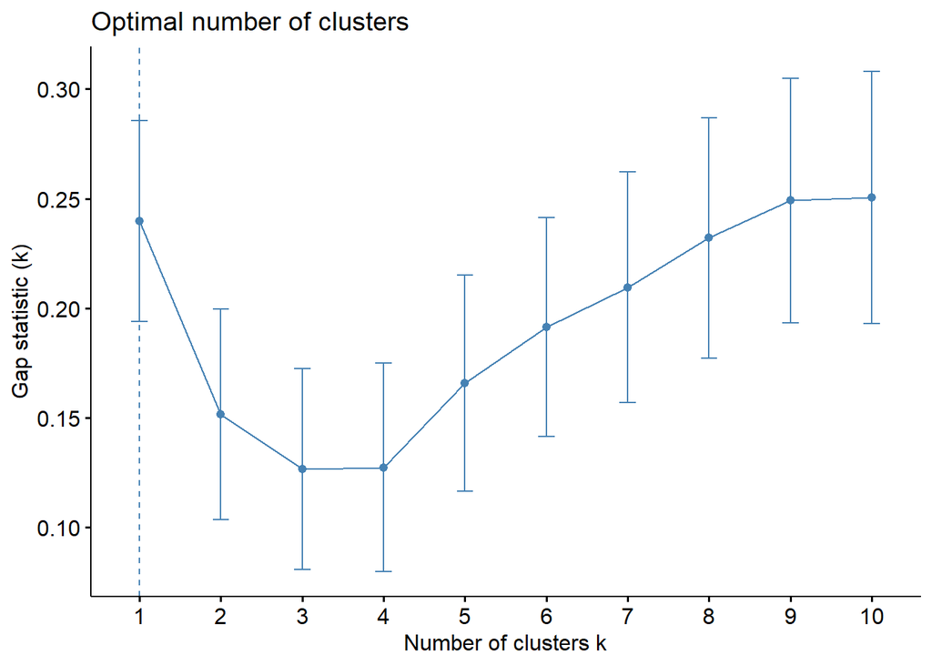

```r
gap_stat <- clusGap(stddata, FUN = kmeans, nstart = 10, K.max = 10, B = 50)

fviz_gap_stat(gap_stat)
```

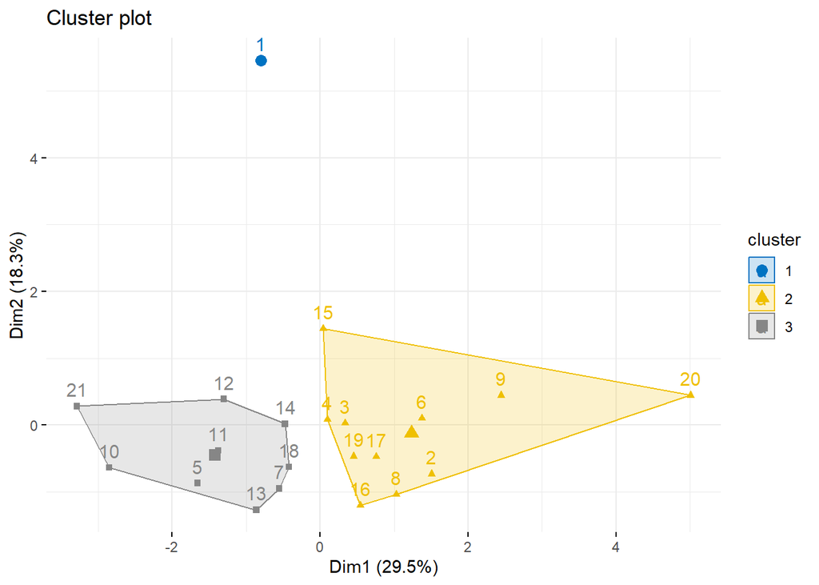

```r
set.seed(123)
## Perform K-means clustering
km.res3 <- kmeans(stddata, 3, nstart = 25)
# Visualize clusters
fviz_cluster(km.res3, data = stddata,
             ellipse.type = "convex",
             palette = "jco",
             ggtheme = theme_minimal())
```

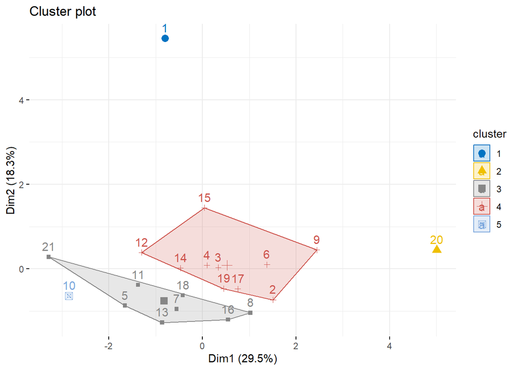

```r
set.seed(123)
## Perform K-means clustering
km.res5 <- kmeans(stddata, 5, nstart = 25)
# Visualize clusters
fviz_cluster(km.res5, data = stddata,
             ellipse.type = "convex",
             palette = "jco",
             ggtheme = theme_minimal())
```

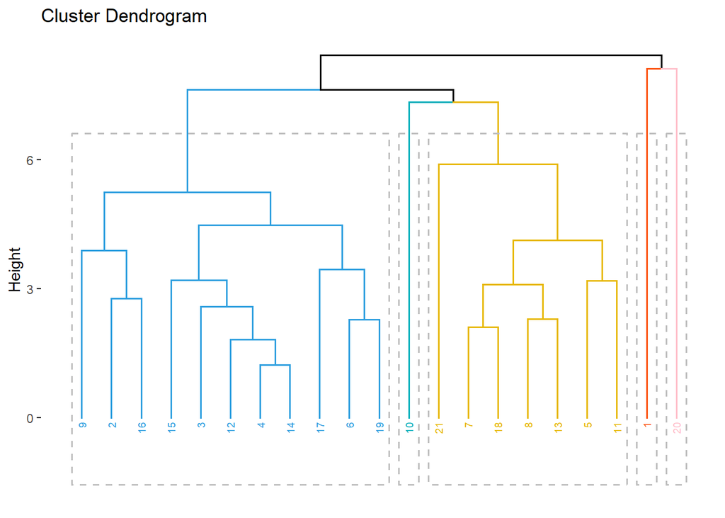

```r
res.hc <- stddata %>% scale() %>% dist(method = "euclidean") %>%
  hclust(method = "ward.D2")  # Change matstd.data to your dataset

# Visualize the Dendrogram
fviz_dend(res.hc, k = 5,  # Cut in four groups
          cex = 0.5,  # label size
          k_colors = c("#2E9FDF", "#00AFBB", "#E7B800", "#FC4E07", "pink"),
          color_labels_by_k = TRUE,  # color labels by groups
          rect = TRUE)
```

## Factor Analysis

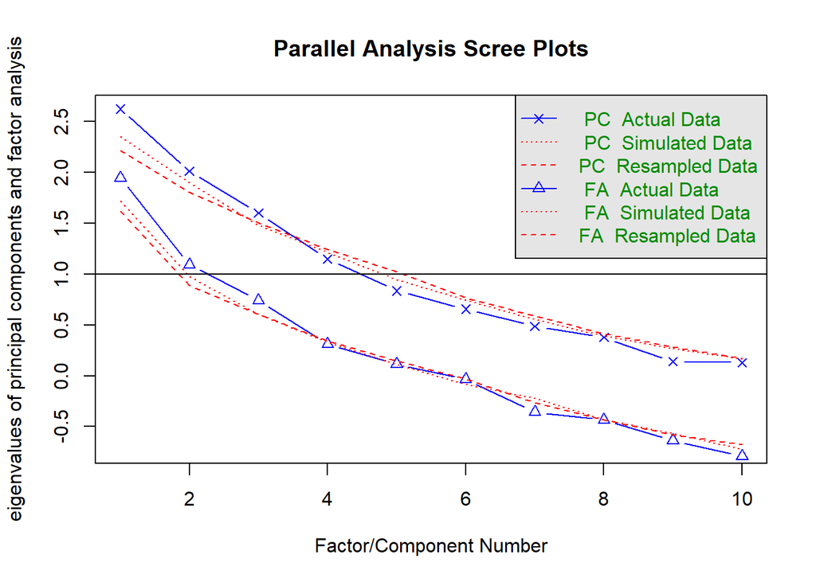

[output not shown]

```r
fa.parallel(data[-1])
```

```r
fit.pc <- principal(data[-1], nfactors=3, rotate="varimax")
fit.pc
```

```
## Principal Components Analysis
## Call: principal(r = data[-1], nfactors = 3, rotate = "varimax")
## Standardized loadings (pattern matrix) based upon correlation matrix
##                              RC1   RC2   RC3   h2   u2 com
## Linkedin                    0.73  0.18  0.00 0.56 0.44 1.1
## Snapchat                    0.58  0.24  0.51 0.66 0.34 2.3
## Twitter                    -0.63  0.48  0.00 0.63 0.37 1.9
## Whatsapp..Wechat            0.57 -0.07  0.31 0.43 0.57 1.6
## Youtube                     0.78 -0.05 -0.11 0.62 0.38 1.1
## OTT                         0.22  0.87  0.16 0.84 0.16 1.2
## Reddit                     -0.16  0.86 -0.18 0.80 0.20 1.2
## Mood.Productivity           0.14  0.27  0.57 0.42 0.58 1.6
## Tired.waking.up.in.morning -0.50 -0.28  0.60 0.69 0.31 2.4
## Trouble.falling.asleep      0.00 -0.17  0.75 0.59 0.41 1.1
##
##                        RC1  RC2  RC3
## SS loadings           2.54 2.01 1.67
## Proportion Var        0.25 0.20 0.17
## Cumulative Var        0.25 0.46 0.62
## Proportion Explained  0.41 0.32 0.27
## Cumulative Proportion 0.41 0.73 1.00
##
## Mean item complexity =  1.5
## Test of the hypothesis that 3 components are sufficient.
##
## The root mean square of the residuals (RMSR) is  0.12
##  with the empirical chi square  26.66  with prob <  0.086
##
## Fit based upon off diagonal values = 0.8
```

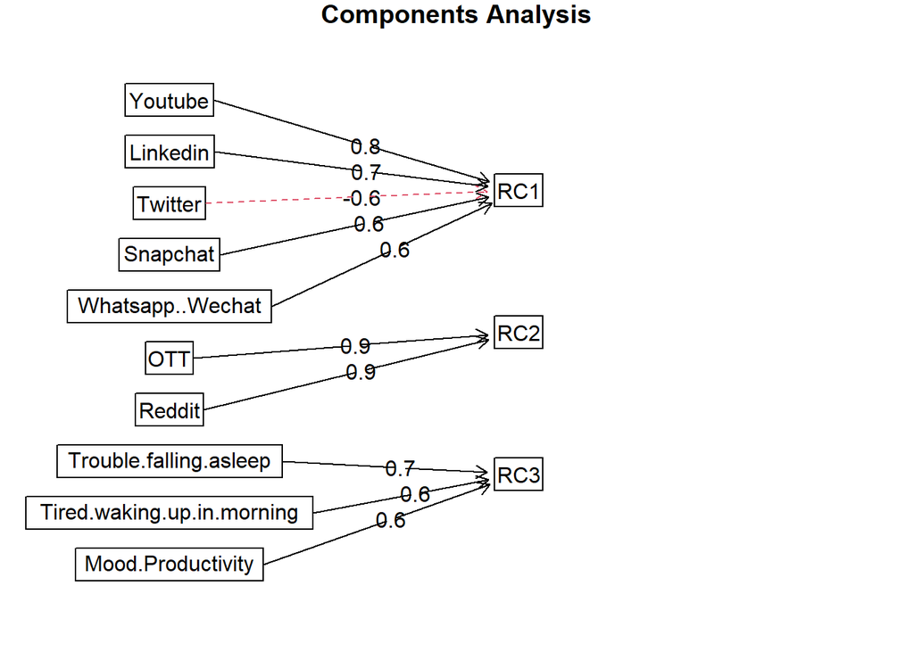

```r
fa.diagram(fit.pc)
```

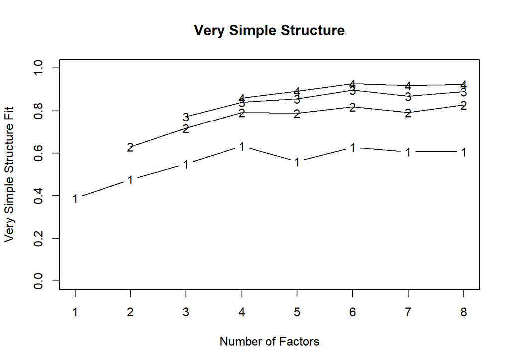

```
##
## Very Simple Structure
## Call: vss(x = data[-1])
## VSS complexity 1 achieves a maximimum of 0.63  with  4  factors
## VSS complexity 2 achieves a maximimum of 0.83  with  8  factors
##
## The Velicer MAP achieves a minimum of 0.07  with  1  factors
## BIC achieves a minimum of  -60.2  with  1  factors
## Sample Size adjusted BIC achieves a minimum of  5.24  with  5  factors
##
## Statistics by number of factors
##   vss1 vss2   map dof   chisq  prob sqresid  fit RMSEA BIC SABIC complex
## 1 0.39 0.00 0.070  35 4.6e+01 0.095    9.94 0.39 0.114 -60  47.8     1.0
## 2 0.48 0.63 0.085  26 2.8e+01 0.362    6.04 0.63 0.034 -51  29.0     1.4
## 3 0.55 0.72 0.099  18 1.8e+01 0.468    3.70 0.77 0.000 -37  18.6     1.5
## 4 0.63 0.79 0.131  11 1.3e+01 0.302    2.30 0.86 0.076 -21  13.3     1.6
## 5 0.56 0.79 0.158   5 5.0e+00 0.413    1.57 0.90 0.000 -10   5.2     1.8
## 6 0.63 0.82 0.192   0 4.4e-01    NA    0.92 0.94    NA  NA    NA     1.7
## 7 0.61 0.79 0.303  -4 6.3e-02    NA    0.64 0.96    NA  NA    NA     1.7
## 8 0.61 0.83 0.487  -7 3.3e-11    NA    0.61 0.96    NA  NA    NA     1.8
##    eChisq    SRMR eCRMS eBIC
## 1 6.7e+01 1.9e-01 0.214  -40
## 2 3.0e+01 1.3e-01 0.166  -49
## 3 1.3e+01 8.3e-02 0.132  -42
## 4 6.1e+00 5.7e-02 0.115  -27
## 5 1.8e+00 3.1e-02 0.092  -13
## 6 1.4e-01 8.5e-03    NA   NA
## 7 9.6e-03 2.3e-03    NA   NA
## 8 3.7e-12 4.4e-08    NA   NA
```

```r
vss(data[-1])
```

# Regression

```r
social_data <- data
```

```r
model_fit <- lm(Mood.Productivity ~ Instagram + Whatsapp..Wechat + Youtube + Linkedin, data = social_data)
summary(model_fit)
```

```
##
## Call:
## lm(formula = Mood.Productivity ~ Instagram + Whatsapp..Wechat +
##     Youtube + Linkedin, data = social_data)
##
## Residuals:
##      Min       1Q   Median       3Q      Max
## -0.69361 -0.03522  0.05435  0.08546  0.28088
##
## Coefficients:
##                  Estimate Std. Error t value Pr(>|t|)
## (Intercept)       0.80547    0.11257   7.155 2.29e-06 ***
## Instagram         0.01220    0.01633   0.747    0.466
## Whatsapp..Wechat  0.01332    0.01404   0.949    0.357
## Youtube          -0.04073    0.03149  -1.294    0.214
## Linkedin          0.03229    0.02158   1.496    0.154
## ---
## Signif. codes:  0 '***' 0.001 '**' 0.01 '*' 0.05 '.' 0.1 ' ' 1
##
## Residual standard error: 0.2082 on 16 degrees of freedom
## Multiple R-squared:  0.2717, Adjusted R-squared:  0.08964
## F-statistic: 1.492 on 4 and 16 DF,  p-value: 0.2512
```

```r
coefficients(model_fit)
```

```
##      (Intercept)        Instagram Whatsapp..Wechat          Youtube
##       0.80547054       0.01219734       0.01332052      -0.04073355
##         Linkedin
##       0.03228542
```

Intercept: FOr one unit increase in (Instagram/Whatsapp..Wechat/Linkedin), the Mood/productivity of a person increases by (0.012/0.013/0.032) respectively. And for one unit increase in YouTube, the Mood decreases by 0.04.

From the Adjusted R-squared value, the model only explains an 8.9% of variance in data. This is not the best model.

2. Model Acceptance

```r
# Assess the acceptance of the model
# Check R-squared and adjusted R-squared
r_squared <- summary(model_fit)$r.squared
adj_r_squared <- summary(model_fit)$adj.r.squared
cat("R-squared:", r_squared, "\n")
```

```
## R-squared: 0.2717105
```

```r
cat("Adjusted R-squared:", adj_r_squared, "\n")
```

```
## Adjusted R-squared: 0.08963814
```

```r
# Check the F-statistic and its p-value
f_statistic <- summary(model_fit)$fstatistic
f_statistic_value <- f_statistic[1]
f_statistic_p_value <- pf(f_statistic_value, f_statistic[2], f_statistic[3], lower.tail = FALSE)
cat("F-statistic:", f_statistic_value, "\n")
```

```
## F-statistic: 1.492321
```

```r
cat("p-value:", f_statistic_p_value, "\n")
```

```
## p-value: 0.2511864
```

Although, R-squared: 0.271 suggests the model explains moderate amount of variance, the F-statistic is 1.49 and p-value is 0.2511, indicating that the model is not significant.

3. Residual Analysis

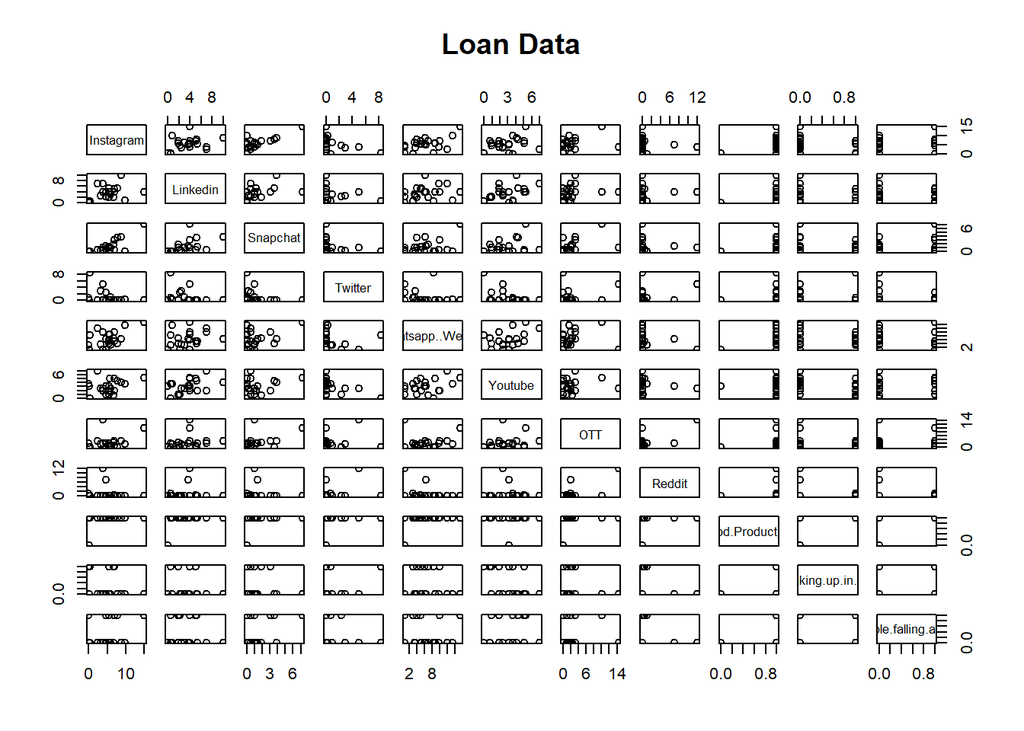

```r
# Select only numeric variables from fish_data
numeric_social_data <- social_data[, sapply(social_data, is.numeric)]
# Plot pairs
pairs(numeric_social_data, main = "Loan Data")
```

```r
confint(model_fit,level=0.95)
```

```
##                        2.5 %     97.5 %
## (Intercept)       0.56683438 1.04410670
## Instagram        -0.02241419 0.04680886
## Whatsapp..Wechat -0.01644818 0.04308921
## Youtube          -0.10748903 0.02602194
## Linkedin         -0.01346124 0.07803208
```

```r
fitted(model_fit)
```

```
##         1         2         3         4         5         6         7         8
## 0.8959893 0.9456530 1.1306838 1.0352185 0.7191153 0.9358631 0.9533123 1.0760560
##         9        10        11        12        13        14        15        16
## 1.1513687 0.6936090 0.9040297 0.8766287 0.9481731 0.9225072 0.9430966 0.9141173
##        17        18        19        20        21
## 0.9832197 1.0137831 0.9145433 1.1054880 0.9375441
```

```r
residuals(model_fit)
```

```
##           1           2           3           4           5           6
##  0.10401071  0.05434699 -0.13068383 -0.03521851  0.28088467  0.06413693
##           7           8           9          10          11          12
##  0.04668773 -0.07605597 -0.15136874 -0.69360904  0.09597027  0.12337135
##          13          14          15          16          17          18
##  0.05182687  0.07749275  0.05690337  0.08588267  0.01678026 -0.01378307
##          19          20          21
##  0.08545668 -0.10548800  0.06245592
```

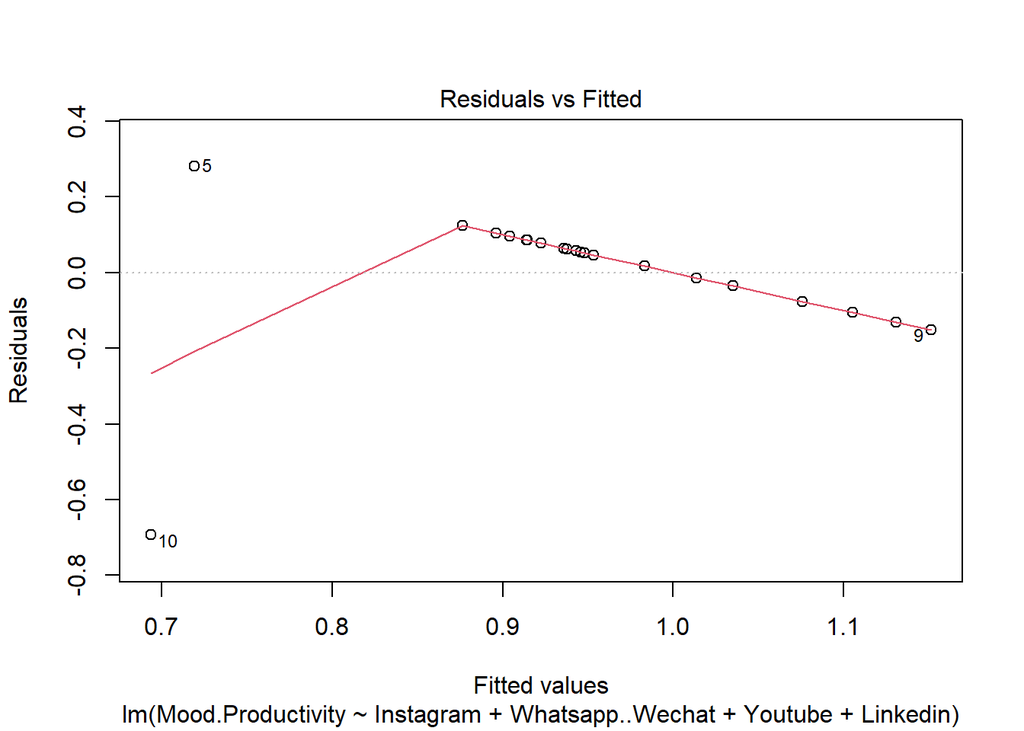

```r
# Plot residuals vs. fitted values
plot(model_fit, which = 1)
```

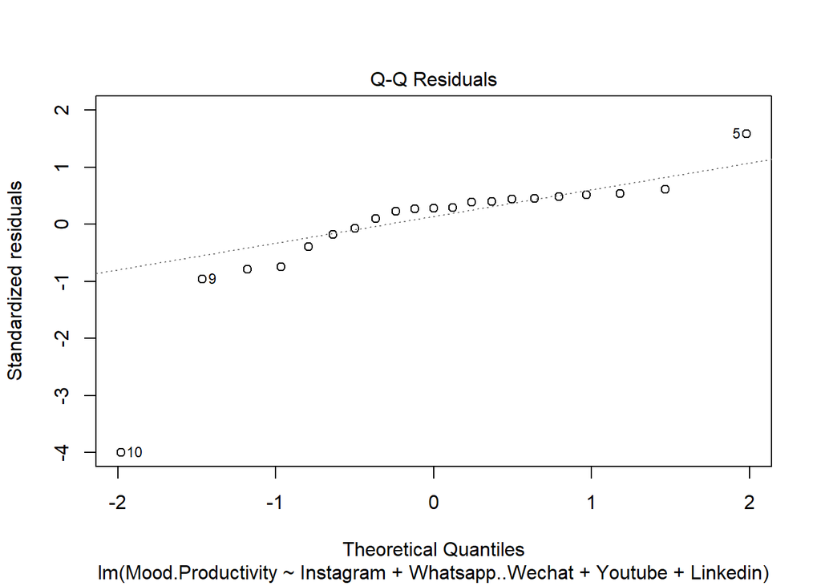

```r
# Plot normal Q-Q plot of residuals
plot(model_fit, which = 2)
```

4. Prediction

```r
# Make predictions
predictions <- predict(model_fit, newdata = social_data)

# Print predictions
print(predictions)
```

```
##         1         2         3         4         5         6         7         8
## 0.8959893 0.9456530 1.1306838 1.0352185 0.7191153 0.9358631 0.9533123 1.0760560
##         9        10        11        12        13        14        15        16
## 1.1513687 0.6936090 0.9040297 0.8766287 0.9481731 0.9225072 0.9430966 0.9141173
##        17        18        19        20        21
## 0.9832197 1.0137831 0.9145433 1.1054880 0.9375441
```

5. Model Accuracy

```r
# Calculate Mean Squared Error (MSE)
mse <- mean(model_fit$residuals^2)

# Calculate Root Mean Squared Error (RMSE)
rmse <- sqrt(mse)

# Calculate Mean Absolute Error (MAE)
mae <- mean(abs(model_fit$residuals))

# Print the accuracy metrics
cat("Mean Squared Error (MSE):", mse, "\n")
```

```
## Mean Squared Error (MSE): 0.033029
```

```r
cat("Root Mean Squared Error (RMSE):", rmse, "\n")
```

```
## Root Mean Squared Error (RMSE): 0.1817388
```

```r
cat("Mean Absolute Error (MAE):", mae, "\n")
```

```
## Mean Absolute Error (MAE): 0.1148769
```

Lower values of MSE, RMSE, and MAE indicate better model performance, with smaller differences between actual and predicted values.

```r
#Anova Table
anova(model_fit)
```

|  | Df | Sum Sq | Mean Sq | F value | Pr(>F) |
| --- | --- | --- | --- | --- | --- |
| Instagram | 1 | 0.11291910 | 0.11291910 | 2.6047895 | 0.1260872 |
| Whatsapp..Wechat | 1 | 0.02198844 | 0.02198844 | 0.5072238 | 0.4865995 |
| Youtube | 1 | 0.02683086 | 0.02683086 | 0.6189276 | 0.4429435 |
| Linkedin | 1 | 0.09703352 | 0.09703352 | 2.2383449 | 0.1540890 |
| Residuals | 16 | 0.69360904 | 0.04335056 | NA | NA |

```r
vcov(model_fit)
```

```
##                    (Intercept)     Instagram Whatsapp..Wechat       Youtube
## (Intercept)       0.0126718369 -4.390599e-04    -3.809262e-04 -0.0012132608
## Instagram        -0.0004390599  2.665684e-04    -1.067892e-04 -0.0000129800
## Whatsapp..Wechat -0.0003809262 -1.067892e-04     1.971908e-04 -0.0001168176
## Youtube          -0.0012132608 -1.298000e-05    -1.168176e-04  0.0009916102
## Linkedin         -0.0005936605 -7.400683e-05     1.009213e-05 -0.0002566724
##                       Linkedin
## (Intercept)      -5.936605e-04
## Instagram        -7.400683e-05
## Whatsapp..Wechat  1.009213e-05
## Youtube          -2.566724e-04
## Linkedin          4.656782e-04
```

```r
cov2cor(vcov(model_fit))
```

```
##                  (Intercept)   Instagram Whatsapp..Wechat     Youtube
## (Intercept)        1.0000000 -0.23889094       -0.2409782 -0.34226609
## Instagram         -0.2388909  1.00000000       -0.4657788 -0.02524642
## Whatsapp..Wechat  -0.2409782 -0.46577881        1.0000000 -0.26417675
## Youtube           -0.3422661 -0.02524642       -0.2641768  1.00000000
## Linkedin          -0.2443855 -0.21005091        0.0333040 -0.37771629
##                    Linkedin
## (Intercept)      -0.2443855
## Instagram        -0.2100509
## Whatsapp..Wechat  0.0333040
## Youtube          -0.3777163
## Linkedin          1.0000000
```

```r
temp <- influence.measures(model_fit)
temp
```

```
## Influence measures of
##   lm(formula = Mood.Productivity ~ Instagram + Whatsapp..Wechat +      Youtube + Linkedin, data = social_data) :
##
##      dfb.1_  dfb.Inst dfb.W..W dfb.Yotb dfb.Lnkd   dffit cov.r   cook.d    hat
## 1   0.13137  0.024408 -0.16480 -0.00189  0.04886  0.2240 1.483 0.010507 0.1515
## 2  -0.00776  0.066623 -0.08944  0.05434  0.01302  0.1288 1.632 0.003519 0.1755
## 3  -0.03258  0.297559 -0.33922  0.34867 -0.43958 -0.6072 1.807 0.075558 0.3748
## 4  -0.02238 -0.000987  0.00557  0.03888 -0.04352 -0.0660 1.561 0.000926 0.1241
## 5   0.57120 -0.501283 -0.12198  0.55582 -0.53513  1.0462 0.812 0.196615 0.2800
## 6  -0.17099 -0.367183  0.24815  0.27295  0.13447  0.5574 3.110 0.065322 0.5870
## 7   0.01812  0.001559 -0.00772  0.00289  0.00658  0.0511 1.430 0.000556 0.0499
## 8  -0.01878 -0.003626 -0.09639  0.10212 -0.03343 -0.1607 1.543 0.005454 0.1483
## 9   0.23719 -0.155946  0.19619  0.11072 -0.68292 -0.8211 1.786 0.135581 0.4246
## 10      NaN       NaN      NaN      NaN      NaN     NaN 0.000 1.413550 0.3064
## 11  0.18583  0.083906 -0.14665 -0.08285 -0.02207  0.2405 1.566 0.012137 0.1882
## 12  0.14681 -0.029685 -0.06010  0.00592 -0.03557  0.1776 1.329 0.006572 0.0793
## 13  0.07676  0.036270 -0.02460 -0.05504 -0.02088  0.1036 1.564 0.002279 0.1370
## 14  0.07001  0.065118 -0.08411 -0.00454 -0.02001  0.1295 1.466 0.003544 0.1029
## 15  0.02539 -0.016138  0.00654  0.00427  0.00432  0.0633 1.420 0.000850 0.0512
## 16 -0.02907  0.064676 -0.11164  0.13476 -0.00282  0.2008 1.562 0.008489 0.1713
## 17 -0.00833  0.022789  0.03397  0.00849 -0.04732  0.0738 2.161 0.001163 0.3631
## 18 -0.01670 -0.010983 -0.00535  0.02251  0.00551 -0.0329 1.676 0.000230 0.1777
## 19 -0.03261 -0.030350  0.03352  0.11740 -0.04050  0.1691 1.500 0.006025 0.1341
## 20  0.39111 -0.493438 -0.17272 -0.16739  0.25504 -0.7882 2.497 0.127946 0.5362
## 21  0.19986 -0.197031  0.22063 -0.18413 -0.03335  0.3425 2.331 0.024771 0.4367
##    inf
## 1
## 2
## 3
## 4
## 5
## 6    *
## 7
## 8
## 9
## 10   *
## 11
## 12
## 13
## 14
## 15
## 16
## 17   *
## 18
## 19
## 20   *
## 21   *
```

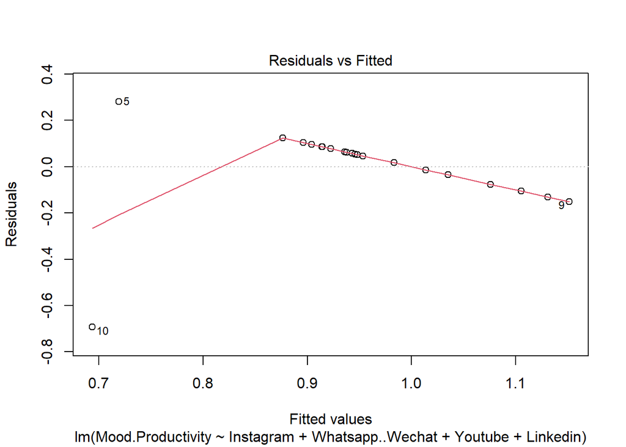

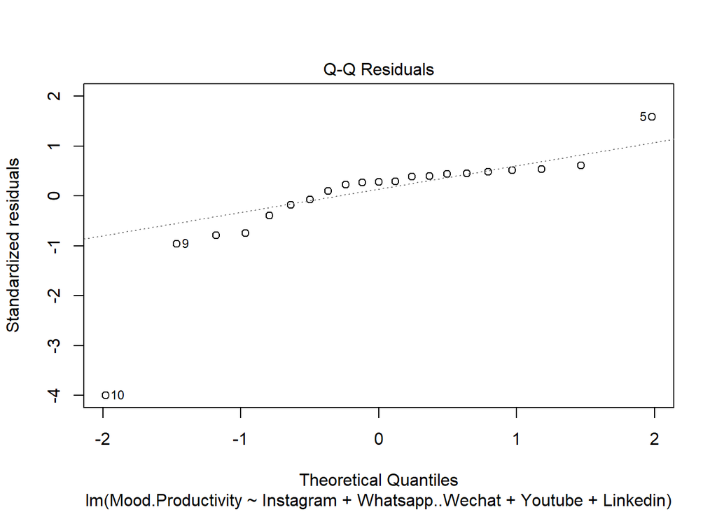

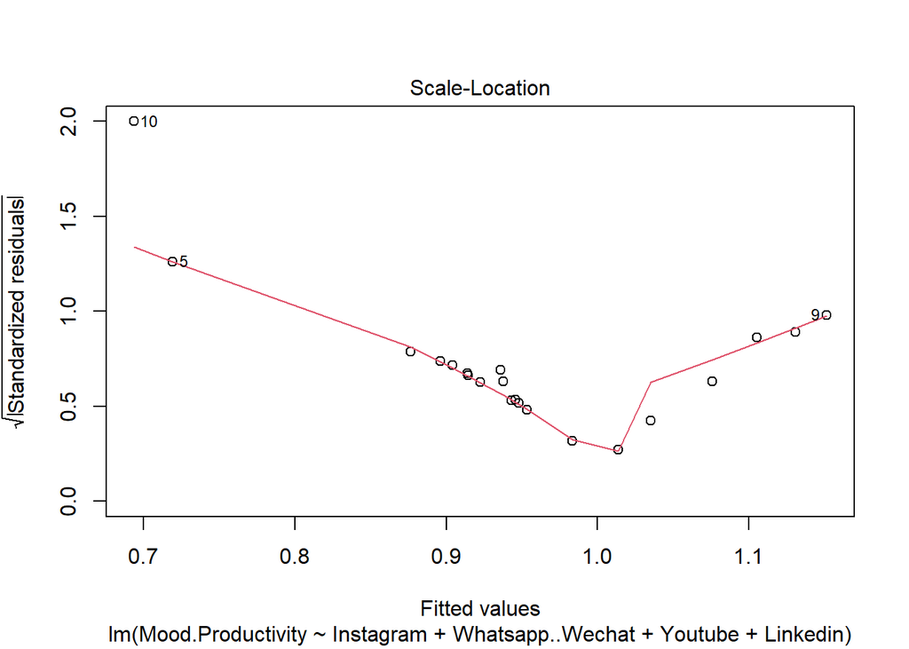

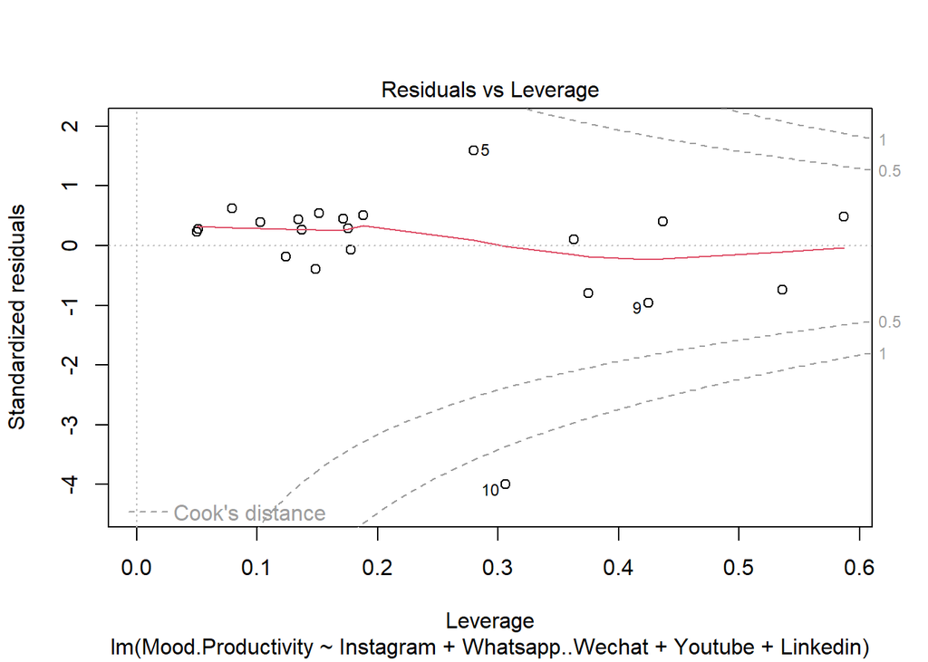

```r
plot(model_fit)
```

```r
anova_result <- anova(model_fit)
print(anova_result)
```

```
## Analysis of Variance Table
##
## Response: Mood.Productivity
##                  Df  Sum Sq  Mean Sq F value Pr(>F)
## Instagram         1 0.11292 0.112919  2.6048 0.1261
## Whatsapp..Wechat  1 0.02199 0.021988  0.5072 0.4866
## Youtube           1 0.02683 0.026831  0.6189 0.4429
## Linkedin          1 0.09703 0.097034  2.2383 0.1541
## Residuals        16 0.69361 0.043351
```

# Logistic Regression

```r
library(ggplot2)
library(cowplot)
library(caret)
library(e1071)
library(pROC)
sapply(social_data, function(x) any(is.na(x)))
```

```
##                  Instagram                   Linkedin
##                      FALSE                      FALSE
##                   Snapchat                    Twitter
##                      FALSE                      FALSE
##           Whatsapp..Wechat                    Youtube
##                      FALSE                      FALSE
##                        OTT                     Reddit
##                      FALSE                      FALSE
##          Mood.Productivity Tired.waking.up.in.morning
##                      FALSE                      FALSE
##     Trouble.falling.asleep
##                      FALSE
```

```r
social_data$Mood.Productivity <- as.factor(social_data$Mood.Productivity)
social_data$Tired.waking.up.in.morning <- as.factor(social_data$Tired.waking.up.in.morning)
social_data$Trouble.falling.asleep <- as.factor(social_data$Trouble.falling.asleep)
str(social_data)
```

```
## 'data.frame':    21 obs. of  11 variables:
##  $ Instagram                 : num  3.8 7.7 3.8 5.4 0 2.3 5.4 7 8.7 0.2 ...
##  $ Linkedin                  : num  4 5.2 7 5.32 0.58 7 4 4 10 0 ...
##  $ Snapchat                  : num  0.96 3.6 0.48 1.2 0 0.48 0 3.12 3.84 0 ...
##  $ Twitter                   : num  5.04 0 0 0 0.72 0 0 0 0 0 ...
##  $ Whatsapp..Wechat          : num  0.96 4.08 9.84 5.28 3.12 ...
##  $ Youtube                   : num  2.4 4.32 1.92 1.92 3.6 6.96 3.12 1.92 4.08 3.12 ...
##  $ OTT                       : num  14.4 0 1.92 1.92 1.92 3.12 0 3.12 3.12 0 ...
##  $ Reddit                    : num  12 0 0 0 0.96 0 0 0 0 0 ...
##  $ Mood.Productivity         : Factor w/ 2 levels "0","1": 2 2 2 2 2 2 2 2 2 1 ...
##  $ Tired.waking.up.in.morning: Factor w/ 2 levels "0","1": 1 1 1 1 2 1 2 2 1 1 ...
##  $ Trouble.falling.asleep    : Factor w/ 2 levels "0","1": 1 2 1 1 2 1 1 2 1 1 ...
```

#1. Model Development

```r
logistic_simple1 <- glm(Tired.waking.up.in.morning ~ Instagram, data=social_data, family="binomial")
summary(logistic_simple1)
```

```
##
## Call:
## glm(formula = Tired.waking.up.in.morning ~ Instagram, family = "binomial",
##     data = social_data)
##
## Coefficients:
##             Estimate Std. Error z value Pr(>|z|)
## (Intercept) -0.09222    0.88544  -0.104    0.917
## Instagram   -0.11658    0.15210  -0.766    0.443
##
## (Dispersion parameter for binomial family taken to be 1)
##
##     Null deviance: 26.734  on 20  degrees of freedom
## Residual deviance: 26.095  on 19  degrees of freedom
## AIC: 30.095
##
## Number of Fisher Scoring iterations: 4
```

```r
logistic_simple2 <- glm(Tired.waking.up.in.morning ~ Linkedin, data=social_data, family="binomial")
summary(logistic_simple2)
```

```
##
## Call:
## glm(formula = Tired.waking.up.in.morning ~ Linkedin, family = "binomial",
##     data = social_data)
##
## Coefficients:
##             Estimate Std. Error z value Pr(>|z|)
## (Intercept)   0.4537     0.8950   0.507    0.612
## Linkedin     -0.3471     0.2488  -1.395    0.163
##
## (Dispersion parameter for binomial family taken to be 1)
##
##     Null deviance: 26.734  on 20  degrees of freedom
## Residual deviance: 24.326  on 19  degrees of freedom
## AIC: 28.326
##
## Number of Fisher Scoring iterations: 4
```

Selecting logistic regression model 2 as my model, has lower AIC value.

```r
logistic <- glm(Tired.waking.up.in.morning ~ ., data=social_data, family="binomial")
summary(logistic)
```

```
##
## Call:
## glm(formula = Tired.waking.up.in.morning ~ ., family = "binomial",
##     data = social_data)
##
## Coefficients:
##                           Estimate Std. Error z value Pr(>|z|)
## (Intercept)              -16.41494 3956.18062  -0.004    0.997
## Instagram                 -0.60848    0.63797  -0.954    0.340
## Linkedin                  -0.61749    0.64755  -0.954    0.340
## Snapchat                   0.09136    0.84730   0.108    0.914
## Twitter                   -0.64240    0.71341  -0.900    0.368
## Whatsapp..Wechat           0.31569    0.29870   1.057    0.291
## Youtube                   -0.42708    0.51526  -0.829    0.407
## OTT                       -0.33419    0.80023  -0.418    0.676
## Reddit                    -0.27620    0.64394  -0.429    0.668
## Mood.Productivity1        20.52901 3956.18411   0.005    0.996
## Trouble.falling.asleep1    2.79667    2.03244   1.376    0.169
##
## (Dispersion parameter for binomial family taken to be 1)
##
##     Null deviance: 26.734  on 20  degrees of freedom
## Residual deviance: 15.481  on 10  degrees of freedom
## AIC: 37.481
##
## Number of Fisher Scoring iterations: 16
```

2. Model Acceptance
3. Residual Analysis and Prediction

```r
#let's  see what this logistic regression predicts
predicted.data <- data.frame(probability.of.tiredwaking=logistic_simple2$fitted.values,Linkedin=social_data$Linkedin)
predicted.data
```

|  | probability.of.tiredwaking | Linkedin |
| --- | --- | --- |
| 1 | 0.28200456 | 4.00 |
| 2 | 0.20570514 | 5.20 |
| 3 | 0.12177611 | 7.00 |
| 4 | 0.19898375 | 5.32 |
| 5 | 0.56276769 | 0.58 |
| 6 | 0.12177611 | 7.00 |
| 7 | 0.28200456 | 4.00 |
| 8 | 0.28200456 | 4.00 |
| 9 | 0.04666843 | 10.00 |
| 10 | 0.61151777 | 0.00 |

[output cut: 11 more lines]

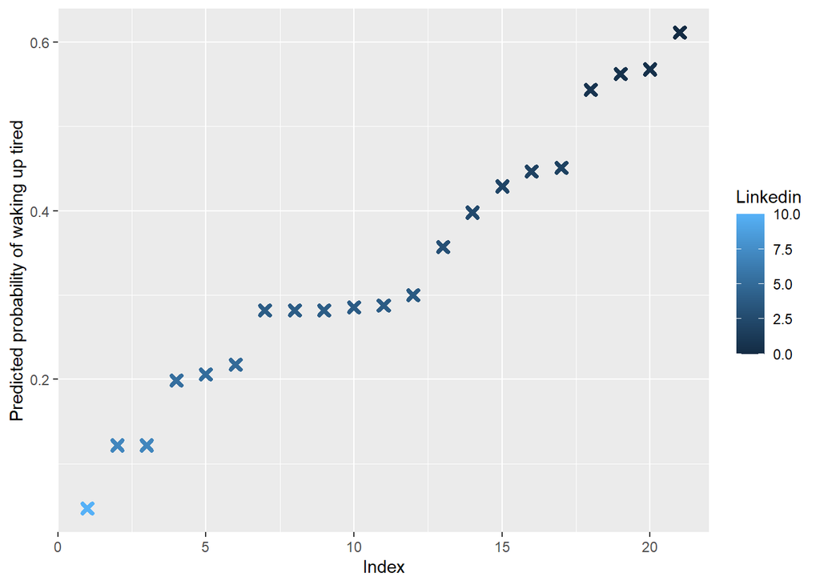

```r
#predicted.data <- data.frame(probability.of.ls=logistic$fitted.values,ls=loan_data$loan_status)
predicted.data <- predicted.data[order(predicted.data$probability.of.tiredwaking, decreasing=FALSE),]
predicted.data$rank <- 1:nrow(predicted.data)
## Lastly, we can plot the predicted probabilities for each sample having
## heart disease and color by whether or not they actually had heart disease
ggplot(data=predicted.data, aes(x=rank, y=probability.of.tiredwaking)) + geom_point(aes(color=Linkedin), alpha=1, shape=4, stroke=2) + xlab("Index") + ylab("Predicted probability of waking up tired")
```

5. Model Accuracy

```r
library(caret)
# Confusion matrix
conf_mat <- table(Actual = ifelse(social_data$Tired.waking.up.in.morning == "1", "Tired", "Not-tired"), Predicted = ifelse(logistic$fitted.values > 0.5, "Tired", "Not-tired"))
print(conf_mat)
```

```
##            Predicted
## Actual      Not-tired Tired
##   Not-tired        13     1
##   Tired             2     5
```

```r
# Calculate accuracy
accuracy <- sum(diag(conf_mat)) / sum(conf_mat)
print(paste("Accuracy:", accuracy))
```

```
## [1] "Accuracy: 0.857142857142857"
```

```r
# Calculate precision
precision <- posPredValue(conf_mat)
print(paste("Precision:", precision))
```

```
## [1] "Precision: 0.928571428571429"
```

```r
# Calculate recall
recall <- conf_mat["Tired", "Tired"] / sum(conf_mat["Tired", ])
print(paste("Recall:", recall))
```

```
## [1] "Recall: 0.714285714285714"
```

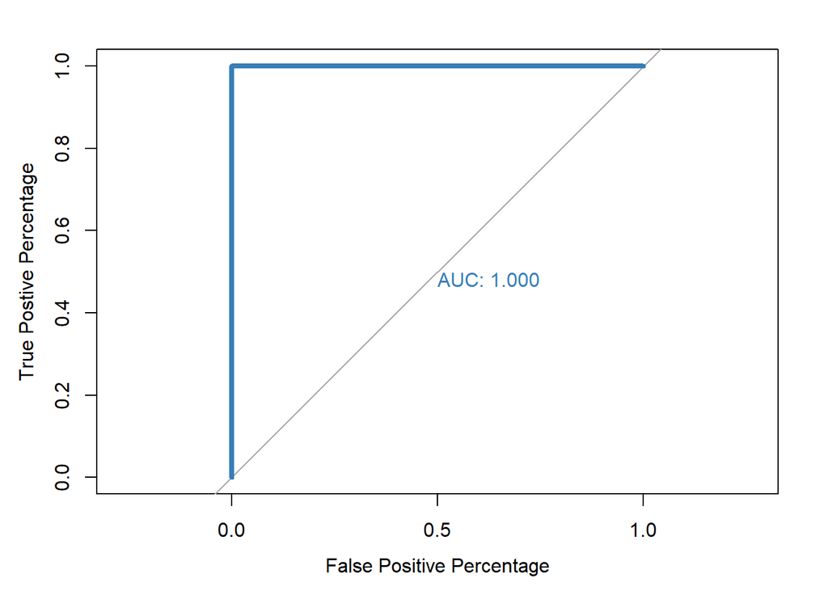

```r
# ROC curve
roc_obj <- roc(social_data$Linkedin, logistic$fitted.values)
plot(roc_obj, xlab="False Positive Percentage", ylab="True Postive Percentage", legacy.axes=TRUE, col="#377eb8", lwd=4, percent=TRUE, print.auc=TRUE)
```

The accuracy of the model is ~86%, that is model correctly predicts whether a person feels tired or not while waking up in the morning.